# Metro Transit Presentation

Elliot Pickens, Elisa Loy, & Joey Caradimitropoulo

May 23, 2019

## Exploring the Data

- We will only be looking at the first week of data
- Observed relationships between variables
- Motivation for transformations
- Initial basic linear models
- Exploring interactions

## Our Approach to the Data

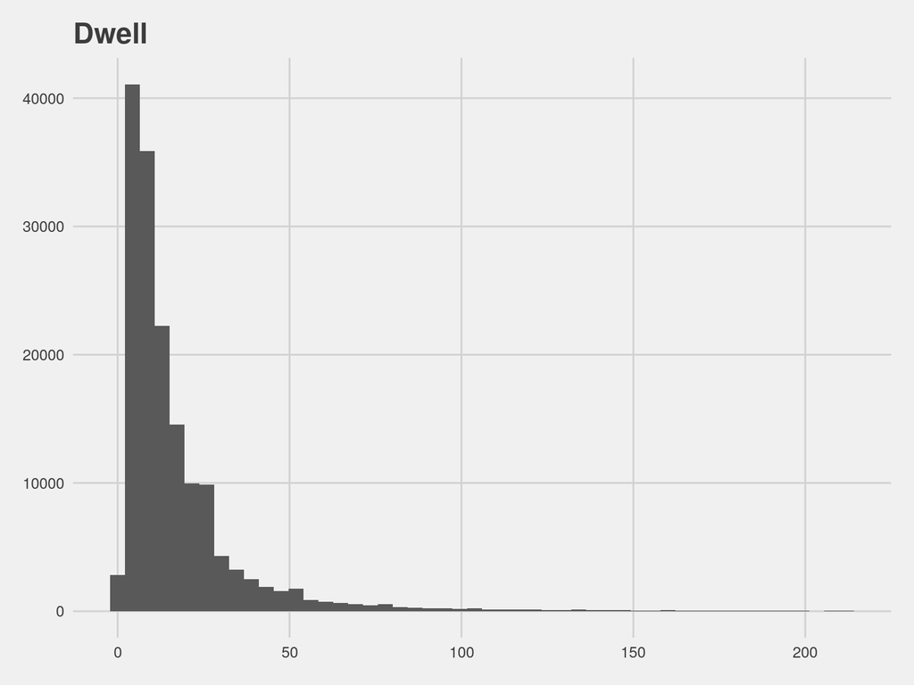

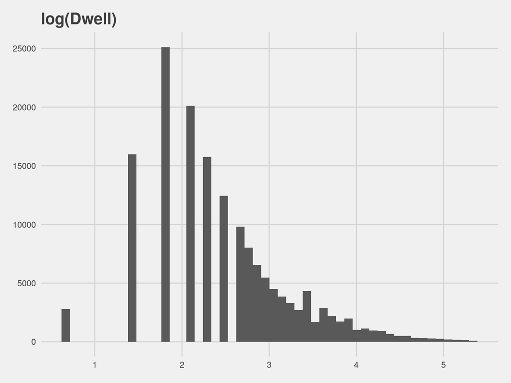

- Logarithmic transformation of the data to account for right skew

## Variable Relationships

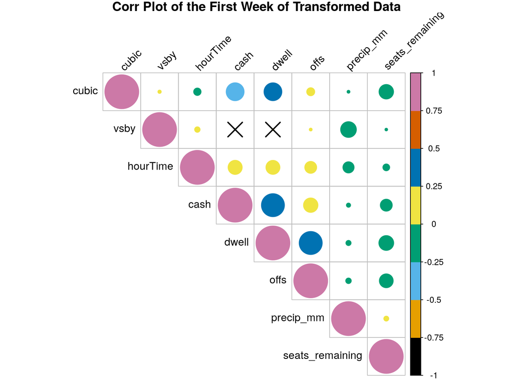

- X lables have been added to correlations with p values $\geq$ 0.01
- What are the relationships between the variables we have been given?

## Exploratory Analysis

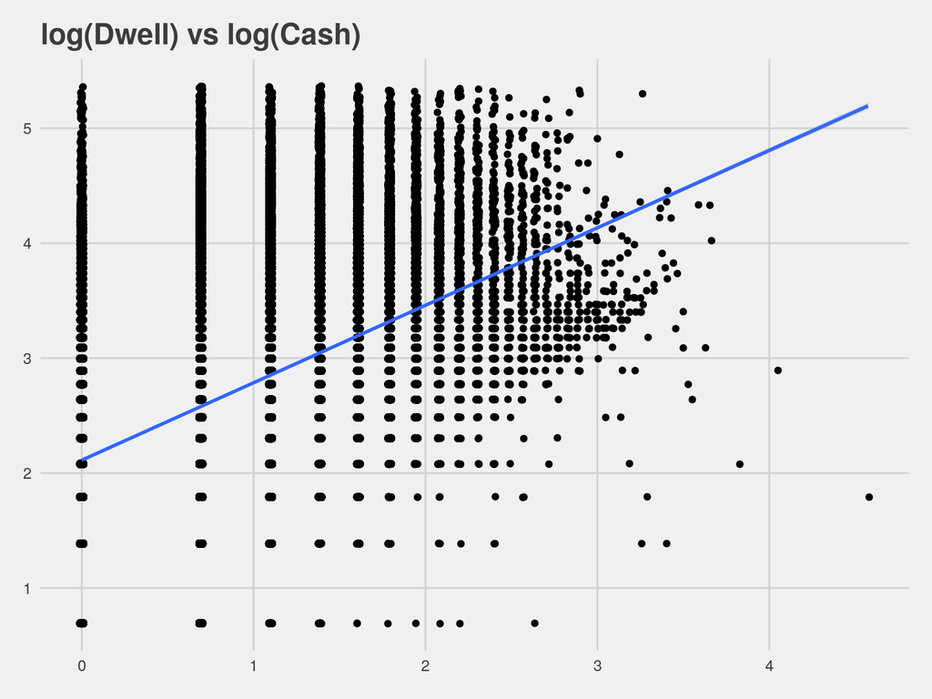

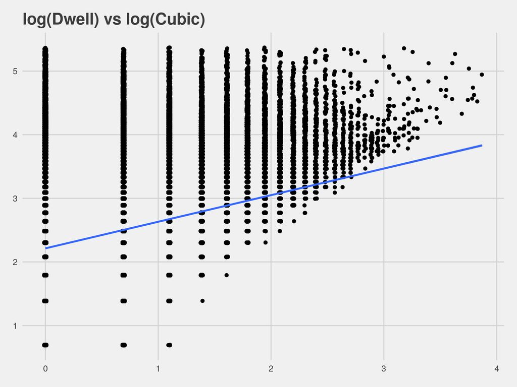

- A look at our initial linear regression model
- Dwell is affected differently depending on the form of payment

## Interactions

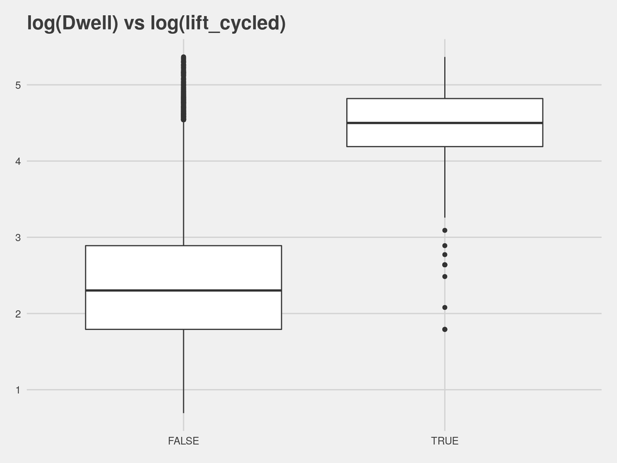

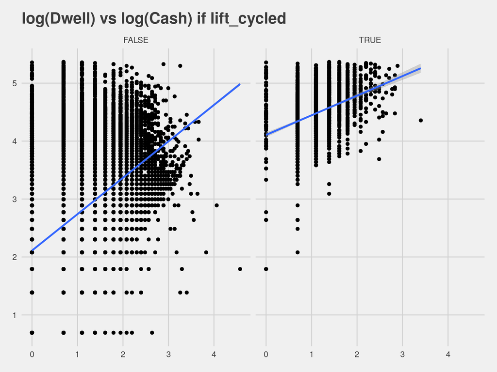

- What happens to cash when lift is cycled vs when it isn’t?
- We included interaction terms to help account for these differences

## Random Effects

- There are still some elements to our model that are still not accounted for in a basic linear model
- What possible groups are we missing?

## Group Differences: line_id & site_id

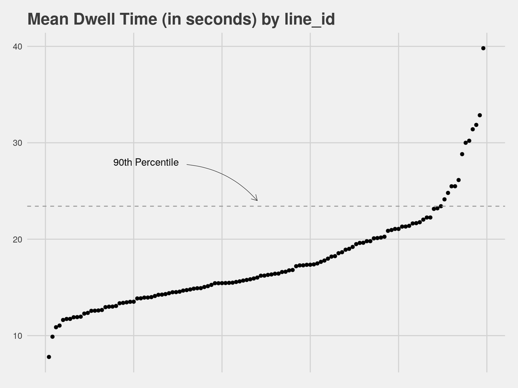

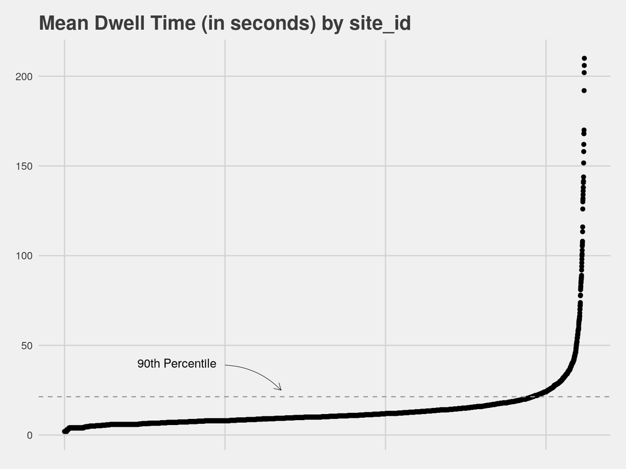

- Site_id and line_id have particularly drastic differences in terms of mean dwell time
- Site_id has a strong relationship with time and the pay-leave pay class

## Spatial Relationships

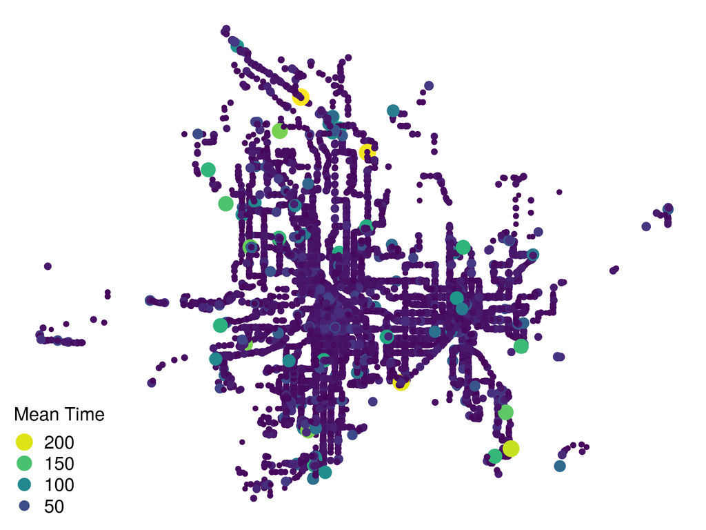

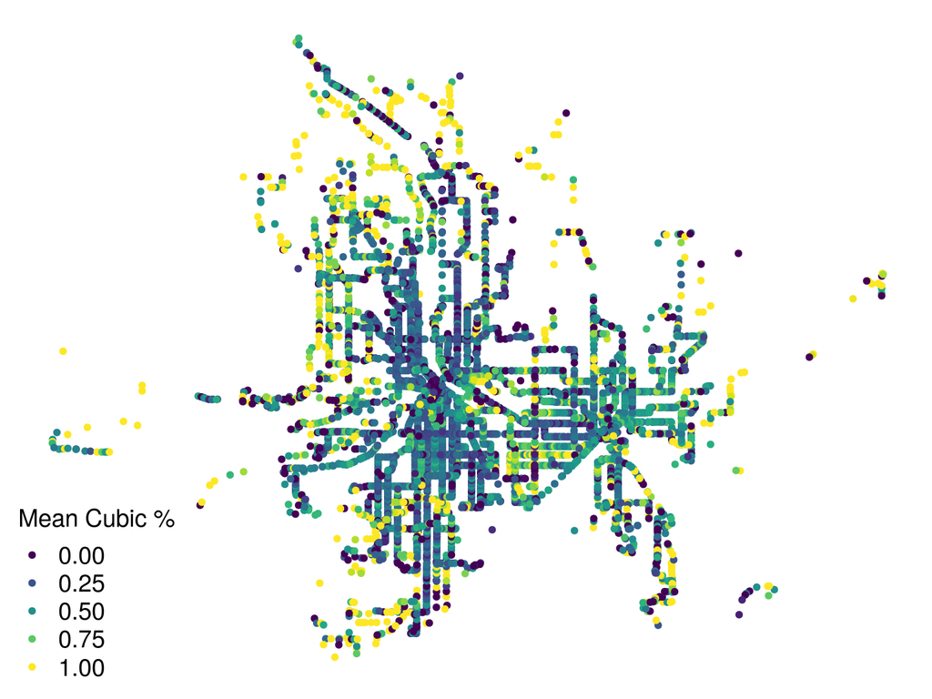

- The stops with the highest mean dwell time appear randomly distributed
- More customers pay using Go-To cards on the outside the city centers

## Random Effects

Conditional and Marginal R^2

| R2m | R2c |
| --- | --- |
| 0.5205499 | 0.6012472 |

```
##  Groups           Name               Std.Dev. Corr
##  site_id:hourTime (Intercept)        0.123091
##                   pay_classOffboard  0.120095 -1.000
##                   pay_classPay-leave 0.076287  0.322 -0.325
##  site_id          (Intercept)        0.142895
##                   pay_classOffboard  0.074281 -1.000
##                   pay_classPay-leave 0.237770  0.148 -0.129
##  line_id          (Intercept)        0.078416
##  hourTime         (Intercept)        0.056950
##                   pay_classOffboard  0.035387 -0.881
##                   pay_classPay-leave 0.012109 -0.986  0.789
##  Residual                            0.479430
```

- Based on the previous two slides, there are clear observable differences  
  between the two groups (site_id and line_id)
  - Based on these observations we believe that there is an underlying hierarchical  
    structure to the data
- 4 random effects: site_id, line_id, time (hour of the day), and time*site_id

## Regression Results: Coefficients and Standard Errors

| Variable | Estimate | Std. Error |
| --- | --- | --- |
| pay_classOffboard | 1.96 | 0.50 |
| lift_cycledTRUE | 1.95 | 0.03 |
| cubic | 1.46 | 0.06 |
| cash | 1.03 | 0.06 |
| (Intercept) | 0.98 | 0.08 |
| bike_activityTRUE | 0.80 | 0.08 |
| offs | 0.61 | 0.00 |
| pay_classOffboard:lift_cycledTRUE | 0.38 | 0.09 |
| pay_classPay-leave:lift_cycledTRUE | 0.25 | 0.08 |
| pay_classPay-leave | 0.15 | 0.22 |
| precip_mm | 0.11 | 0.08 |
| seats_remaining | 0.07 | 0.02 |
| pay_classPay-leave:seats_remaining | 0.01 | 0.05 |
| cash:seats_remaining | 0.01 | 0.01 |
| cubic:seats_remaining | -0.12 | 0.01 |
| cubic:lift_cycledTRUE | -0.14 | 0.02 |
| offs:cubic | -0.19 | 0.00 |
| offs:cash | -0.21 | 0.00 |
| lift_cycledTRUE:cash | -0.21 | 0.02 |
| offs:lift_cycledTRUE | -0.28 | 0.02 |
| offs:bike_activityTRUE | -0.31 | 0.06 |
| cubic:cash | -0.35 | 0.01 |
| pay_classOffboard:cash | -0.35 | 0.02 |
| pay_classPay-leave:cash | -0.40 | 0.02 |
| pay_classOffboard:seats_remaining | -0.46 | 0.12 |

## Model Limitations

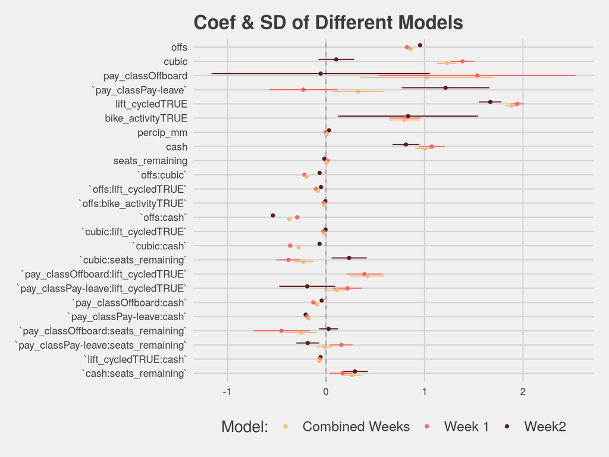

- There are clear disagreements between the models
- In particular, pay class and interactions with the variable
  - We are hesitent to fit our model on the combined data

## Data Constraints

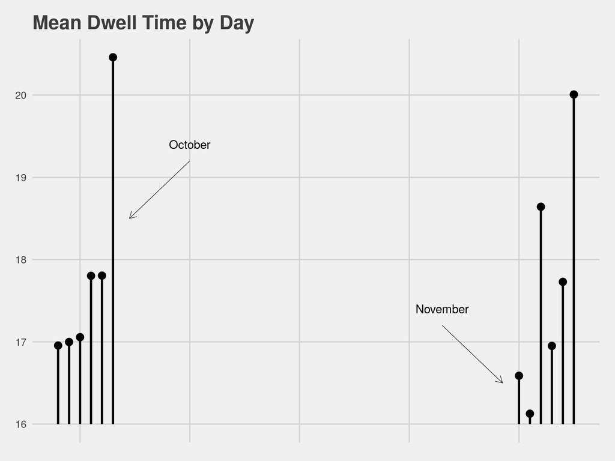

- Limited time frame (only 2 weeks of data)
- What other trends might we see with more data?

## Weather Constraints

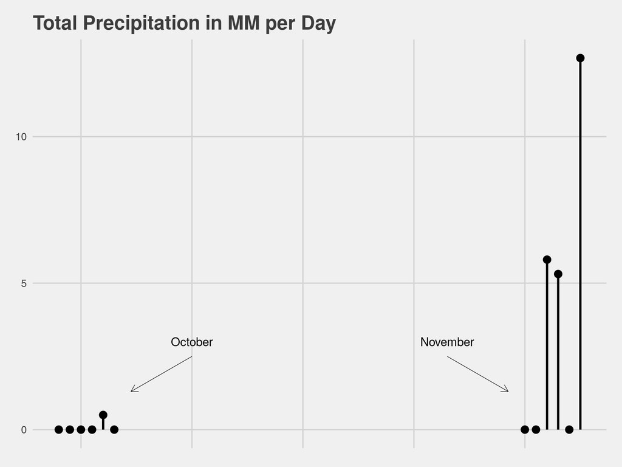

## Conclusion

- Our model is an inferential model, not a predictive model
- We hope to illustrate that certain variables and the interaction  
  between them lead to quite different effects on mean dwell time
- With the input of more data, Metro Transit’s team would be able to  
  develop a model capable of prediction

## Thank You! Questions?

- Thank you to Prof. Andy Poppick and Eric Lind